# Precio por zona

Toni

2025-05-25

# LECTURA DE DATOS + LIBRERIAS

Para realizar el estudio de precio de alquiler de airbnb por barrios se necesita el fichero obtenido a partir de la limpieza de listings (sin las reseñas)

```r
pisos = read.csv2("listings_valenciaAAA.csv", sep = ',')
# Convertimos a numéricas las variables que se cargan como texto
pisos$bathrooms <- round(as.numeric(as.factor(pisos$bathrooms)))
pisos$review_scores_rating <- as.numeric(as.factor(pisos$review_scores_rating))
pisos$review_scores_accuracy <- as.numeric(as.factor(pisos$review_scores_accuracy))
pisos$review_scores_cleanliness <- as.numeric(as.factor(pisos$review_scores_cleanliness))
pisos$review_scores_checkin <- as.numeric(as.factor(pisos$review_scores_checkin))
pisos$review_scores_communication <- as.numeric(as.factor(pisos$review_scores_communication))
pisos$review_scores_location <- as.numeric(as.factor(pisos$review_scores_location))
pisos$review_scores_value <- as.numeric(as.factor(pisos$review_scores_value))
pisos$reviews_per_month <- as.numeric(as.factor(pisos$reviews_per_month))
head(pisos)
```

```
##   X listing_id                                          name
## 1 1      48154                 Precioso apartamento con wifi
## 2 2     137143                PENTHOUSE  ON FRONT LINE BEACH
## 3 3     165971                      ★ Architectural touch! ★
## 4 4     169284                       Apartment near downtown
## 5 5     182221            Apartments Calatrava City Valencia
## 6 6     192674 Modern 2 br in El Carmen -  Parking Available
##                                                                                                                                                                                                                                                                                                          …
## 1 Second floor on a farm from the late 19th century, very beautiful and completely renovated, preserving old elements such as wooden beams in the ceiling. It consists of two bedrooms, with an integrated kitchen and bathroom. Located on Calle Sagunto, a five-minute walk from the historic center (t…
## 2                                                                                                                                                                                                                                                                                                        …
## 3                                                                                                                                                          Hola! I am ready to welcome you in my apt., which was my first work as an architect. I designed it with special dedication & care, and hope yo…
## 4                                                                                                                                                                                                                                                                                                        …
## 5                                                                                                                                                                                                                                                                                                        …
## 6                                                                                                                                                                                                                                 Lovely 2 bedroom 2 bath apartment in the heart of the old city of Valen…
##                                                                                                                                                                                                                                                                                                          …
```

[output cut: 97 more lines]

Librerias que se van a utilizar:

```r
library(dplyr)
library(sf)
library(ggplot2)
library(viridis)
library(grid)
library(gridExtra)
library(factoextra)
library(readr)
library(leaflet)
```

# ANÁLISIS DE BARRIOS

Una vez se ha leído el fichero correctamente, ser observan algunos parámetros estadísticos que pueden ser útiles para este análisis, como es el caso de la media, la mediana o la desviación típica del la variable price(precio del alquiler).

```r
pisos %>%
  group_by(pisos$neighbourhood_cleansed) %>%
  summarise(
    media = mean(price, na.rm = TRUE),
    mediana = median(price, na.rm = TRUE),
    sd = sd(price, na.rm = TRUE),
    n = n()
  ) %>%
  arrange(desc(media))
```

```
## # A tibble: 78 × 5
##    `pisos$neighbourhood_cleansed` media mediana    sd     n
##    <chr>                          <dbl>   <dbl> <dbl> <int>
##  1 CARPESA                         400     400   NA       1
##  2 LA GRAN VIA                     224.    150. 172.     30
##  3 EL PLA DEL REMEI                197.    166. 159.     14
##  4 CAMI REAL                       168.    168. 159.      2
##  5 JAUME ROIG                      158.    158.  60.1     2
##  6 EL SALER                        145.    125   77.4    23
##  7 LA XEREA                        143.    109  102.     51
##  8 PENYA-ROJA                      141.    131   70.3    52
##  9 MAHUELLA-TAULADELLA             140     140   NA       1
## 10 ALBORS                          133.    110   84.6    31
## # ℹ 68 more rows
```

Ahora se va mostrar un mapa de calor y gráficos boxplot para visualizar mejor el precio por barrio, pero antes hay que juntar dos archivos. El archivo geojson de la ciudad de valencia con el de listings, para poder visualizar los datos.

```r
barrios <- st_read("valencia.geojson")  # Asegúrate de que el archivo esté en tu directorio de trabajo
# Calcular estadísticas por barrio
precios_zona <- pisos %>%
  group_by(neighbourhood_cleansed) %>%
  summarise(
    media_precio = mean(price, na.rm = TRUE)
  )

# Unir los datos espaciales con los precios
# Asegúrate de que el nombre de la columna en 'barrios' que contiene los nombres de los barrios coincida con 'neighbourhood_group_cleansed'
# Por ejemplo, si la columna se llama 'nombre_barrio', ajusta el código así:
barrios_precios <- barrios %>%
  left_join(precios_zona, by = c("nombre" = "neighbourhood_cleansed"))
```

A continuación se muestra el mapa:

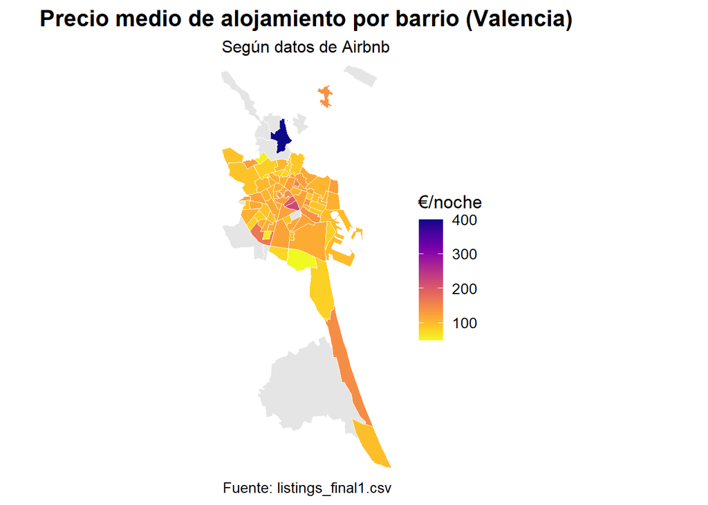

```r
ggplot(data = barrios_precios) +
  geom_sf(aes(fill = media_precio),
          color = "white",
          size = 0.3,
          show.legend = TRUE) +
  scale_fill_viridis(
    option = "plasma",
    name = "€/noche",
    na.value = "grey90",
    direction = -1
  ) +
  coord_sf(expand = FALSE) +
  labs(
    title = "Precio medio de alojamiento por barrio (Valencia)",
    subtitle = "Según datos de Airbnb",
    caption = "Fuente: listings_final1.csv"
  ) +
  theme_minimal(base_size = 13) +
  theme(
    legend.position = "right",
    plot.title = element_text(face = "bold", size = 16, hjust = 0.5),
    plot.subtitle = element_text(size = 12, hjust = 0.5),
    axis.text = element_blank(),
    axis.ticks = element_blank(),
    panel.grid = element_blank()
  )
```

Se observa que el mapa sale distorsionado y no se puede comprobar bien la información, por un barrio con un precio muy elevado, hay que realizar una comprobación para solucionarlo, se va a ver con más detalle con los gráficos boxplot.

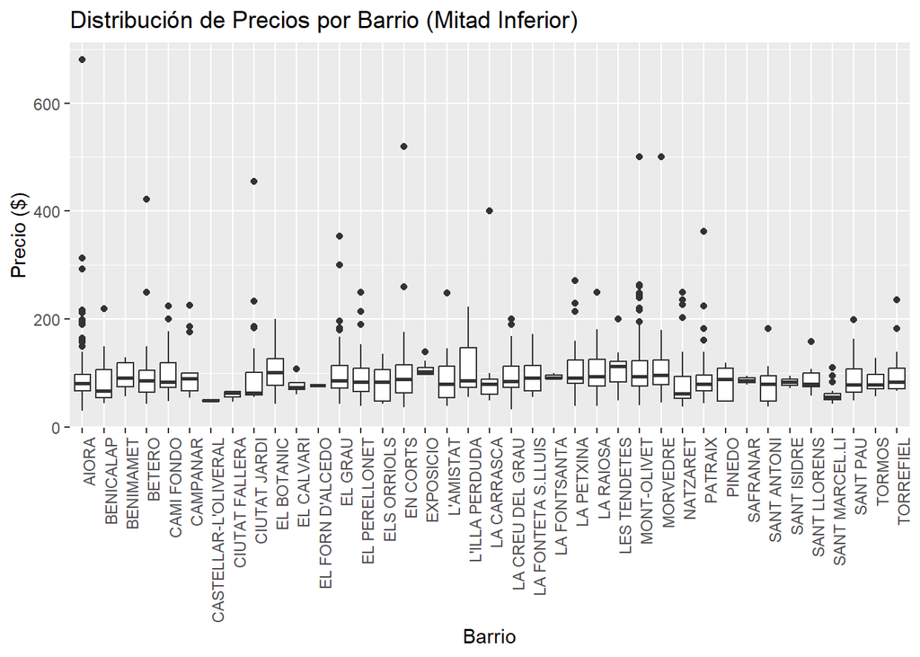

```r
# Calcular la media de los precios por barrio
precios_por_barrio <- pisos %>%
  group_by(neighbourhood_cleansed) %>%
  summarise(media_precio = mean(price, na.rm = TRUE))

# Ordenar los barrios por la media de los precios
precios_por_barrio <- precios_por_barrio %>%
  arrange(media_precio)

# Dividir los barrios en dos grupos (la mitad inferior y la mitad superior por precio)
mitad_inferior <- precios_por_barrio[1:(nrow(precios_por_barrio) %/% 2), ]
mitad_superior <- precios_por_barrio[(nrow(precios_por_barrio) %/% 2 + 1):nrow(precios_por_barrio), ]

# Filtrar los datos originales para obtener solo los barrios de cada mitad
pisos_mitad_inferior <- pisos %>% filter(neighbourhood_cleansed %in% mitad_inferior$neighbourhood_cleansed)
pisos_mitad_superior <- pisos %>% filter(neighbourhood_cleansed %in% mitad_superior$neighbourhood_cleansed)

# Boxplot para la mitad inferior de barrios
ggplot(pisos_mitad_inferior, aes(x = neighbourhood_cleansed, y = price)) +
  geom_boxplot() +
  labs(title = "Distribución de Precios por Barrio (Mitad Inferior)", x = "Barrio", y = "Precio ($)") +
  theme(axis.text.x = element_text(angle = 90, hjust = 1))
```

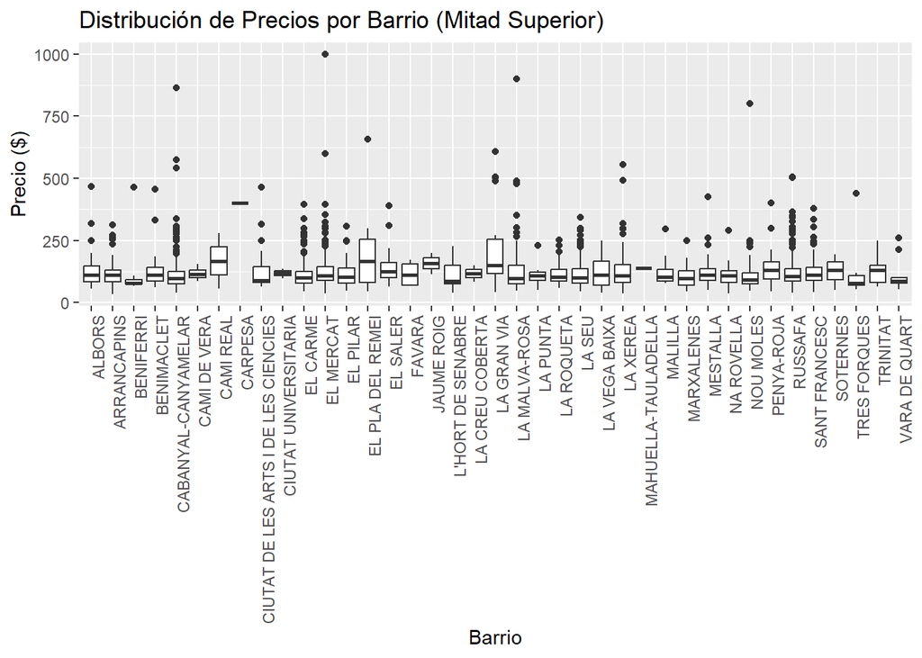

```r
# Boxplot para la mitad superior de barrios
ggplot(pisos_mitad_superior, aes(x = neighbourhood_cleansed, y = price)) +
  geom_boxplot() +
  labs(title = "Distribución de Precios por Barrio (Mitad Superior)", x = "Barrio", y = "Precio ($)") +
  theme(axis.text.x = element_text(angle = 90, hjust = 1))
```

En este gráfico no se puede comprobar mucho debido a la cantidad de atípicos que hay, por ello se va a realizar el mismo gráfico pero filtrado por un precio más bajo:

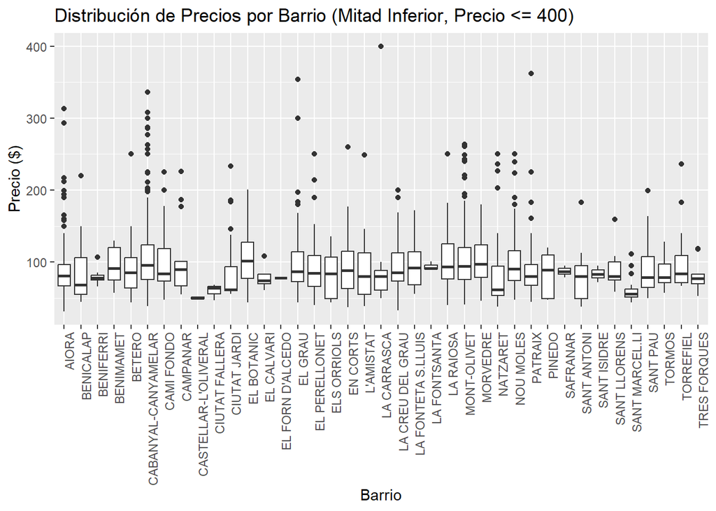

```r
# Filtrar los datos para incluir solo los precios menores o iguales a 400
pisos_filtrados <- pisos %>%
  filter(price <= 400)

# Calcular la media de los precios por barrio para los datos filtrados
precios_por_barrio_filtrados <- pisos_filtrados %>%
  group_by(neighbourhood_cleansed) %>%
  summarise(media_precio = mean(price, na.rm = TRUE))

# Ordenar los barrios por la media de los precios filtrados
precios_por_barrio_filtrados <- precios_por_barrio_filtrados %>%
  arrange(media_precio)

# Dividir los barrios en dos grupos (la mitad inferior y la mitad superior por precio filtrado)
mitad_inferior_filtrada <- precios_por_barrio_filtrados[1:(nrow(precios_por_barrio_filtrados) %/% 2), ]
mitad_superior_filtrada <- precios_por_barrio_filtrados[(nrow(precios_por_barrio_filtrados) %/% 2 + 1):nrow(precios_por_barrio_filtrados), ]

# Filtrar los datos originales para obtener solo los barrios de cada mitad
pisos_mitad_inferior_filtrada <- pisos_filtrados %>%
  filter(neighbourhood_cleansed %in% mitad_inferior_filtrada$neighbourhood_cleansed)

pisos_mitad_superior_filtrada <- pisos_filtrados %>%
  filter(neighbourhood_cleansed %in% mitad_superior_filtrada$neighbourhood_cleansed)

# Boxplot para la mitad inferior de barrios filtrados
ggplot(pisos_mitad_inferior_filtrada, aes(x = neighbourhood_cleansed, y = price)) +
  geom_boxplot() +
  labs(title = "Distribución de Precios por Barrio (Mitad Inferior, Precio <= 400)", x = "Barrio", y = "Precio ($)") +
  theme(axis.text.x = element_text(angle = 90, hjust = 1))
```

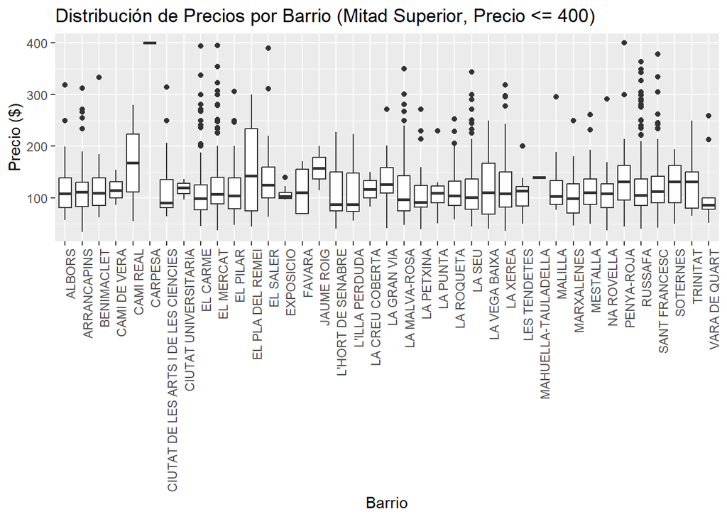

```r
# Boxplot para la mitad superior de barrios filtrados
ggplot(pisos_mitad_superior_filtrada, aes(x = neighbourhood_cleansed, y = price)) +
  geom_boxplot() +
  labs(title = "Distribución de Precios por Barrio (Mitad Superior, Precio <= 400)", x = "Barrio", y = "Precio ($)") +
  theme(axis.text.x = element_text(angle = 90, hjust = 1))
```

```r
# Definir el umbral mínimo de observaciones
umbral_minimo <- 5

# Calcular el número de observaciones por barrio
observaciones_por_barrio <- pisos_filtrados %>%
  group_by(neighbourhood_cleansed) %>%
  summarise(n = n())

# Filtrar los barrios con al menos el umbral mínimo de observaciones
barrios_filtrados <- observaciones_por_barrio %>%
  filter(n >= umbral_minimo)

# Filtrar los datos originales para incluir solo los barrios con suficientes observaciones
pisos_filtrados <- pisos %>%
  filter(neighbourhood_cleansed %in% barrios_filtrados$neighbourhood_cleansed)
```

Para comprobar que no se detecta ninguna anomalía más se vuelve a mostrar el mapa de calor:

```r
# Calcular estadísticas por barrio
precios_zona <- pisos_filtrados %>%
  group_by(neighbourhood_cleansed) %>%
  summarise(
    media_precio = mean(price, na.rm = TRUE)
  )

# Unir los datos espaciales con los precios
# Asegúrate de que el nombre de la columna en 'barrios' que contiene los nombres de los barrios coincida con 'neighbourhood_group_cleansed'
# Por ejemplo, si la columna se llama 'nombre_barrio', ajusta el código así:
barrios_precios <- barrios %>%
  left_join(precios_zona, by = c("nombre" = "neighbourhood_cleansed"))
```

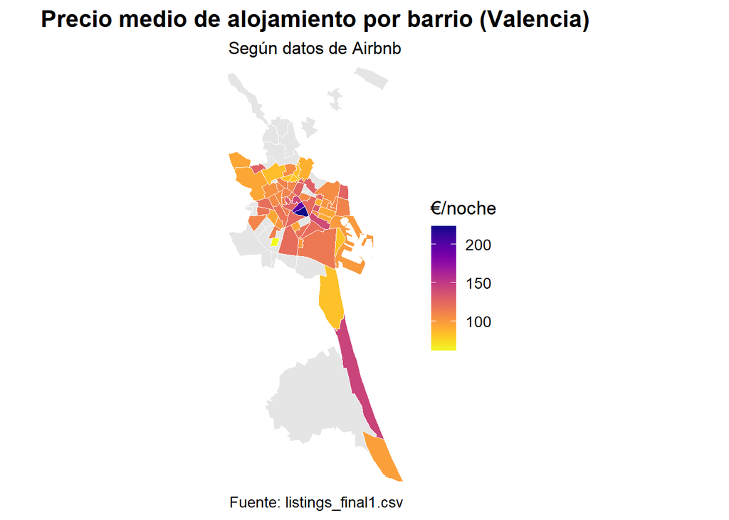

```r
ggplot(data = barrios_precios) +
  geom_sf(aes(fill = media_precio),
          color = "white",
          size = 0.3,
          show.legend = TRUE) +
  scale_fill_viridis(
    option = "plasma",
    name = "€/noche",
    na.value = "grey90",
    direction = -1
  ) +
  coord_sf(expand = FALSE) +
  labs(
    title = "Precio medio de alojamiento por barrio (Valencia)",
    subtitle = "Según datos de Airbnb",
    caption = "Fuente: listings_final1.csv"
  ) +
  theme_minimal(base_size = 13) +
  theme(
    legend.position = "right",
    plot.title = element_text(face = "bold", size = 16, hjust = 0.5),
    plot.subtitle = element_text(size = 12, hjust = 0.5),
    axis.text = element_blank(),
    axis.ticks = element_blank(),
    panel.grid = element_blank()
  )
```

Ahora se observa que los precios más altos se muestran en el centro, así que se va a comprobar de nuevo:

```r
pisos_filtrados %>%
  group_by(pisos_filtrados$neighbourhood_cleansed) %>%
  summarise(
    media = mean(price, na.rm = TRUE),
    mediana = median(price, na.rm = TRUE),
    sd = sd(price, na.rm = TRUE),
    n = n()
  ) %>%
  arrange(desc(media))
```

```
## # A tibble: 62 × 5
##    `pisos_filtrados$neighbourhood_cleansed` media mediana    sd     n
##    <chr>                                    <dbl>   <dbl> <dbl> <int>
##  1 LA GRAN VIA                               224.    150. 172.     30
##  2 EL PLA DEL REMEI                          197.    166. 159.     14
##  3 EL SALER                                  145.    125   77.4    23
##  4 LA XEREA                                  143.    109  102.     51
##  5 PENYA-ROJA                                141.    131   70.3    52
##  6 ALBORS                                    133.    110   84.6    31
##  7 EL MERCAT                                 131.    107   94.7   183
##  8 BENIMACLET                                129.    110   80.0    31
##  9 BENIFERRI                                 128.     78  136.      8
## 10 SANT FRANCESC                             127.    112   59.8   113
## # ℹ 52 more rows
```

Ahora los barrios con alquileres más caros son bastante representativos así que no se va a realizar ninguna filtración más.

# PRECIO_PONDERADO

Pero antes de realizar ningún estudio hay que tener en cuenta que la variable precio por si sola realmente no explica correctamente las diferencias de precios entre barrios, habría que crear una nueva variable ponderada por otras variables que también afecten al precio.

En el dataset de listings solo se tienen las siguientes variables descriptivas de la vivienda: nº de habitaciones, nº de baños, nº deacommodates y una lista de servicios, por lo que se va a realizar una regresión lineal para comprobar cuanto afecta cada variable respectivamente al precio (price).

```r
# Convertir la lista de servicios en numerico contando cuanto hay
pisos_filtrados$num_amenities <- sapply(pisos_filtrados$amenities, function(x) length(unlist(strsplit(as.character(x), ",\\s*"))))
```

```r
summary(lm(price ~ bedrooms + bathrooms + accommodates + num_amenities, data = pisos_filtrados))
```

```
##
## Call:
## lm(formula = price ~ bedrooms + bathrooms + accommodates + num_amenities,
##     data = pisos_filtrados)
##
## Residuals:
##     Min      1Q  Median      3Q     Max
## -163.97  -30.26   -9.12   16.13  922.50
##
## Coefficients:
##               Estimate Std. Error t value Pr(>|t|)
## (Intercept)    1.67510    4.94684   0.339    0.735
## bedrooms       8.73913    1.58795   5.503    4e-08 ***
## bathrooms     14.73539    1.31547  11.202   <2e-16 ***
## accommodates  11.95200    0.93626  12.766   <2e-16 ***
## num_amenities -0.07774    0.07945  -0.978    0.328
## ---
## Signif. codes:  0 '***' 0.001 '**' 0.01 '*' 0.05 '.' 0.1 ' ' 1
##
## Residual standard error: 60.96 on 3425 degrees of freedom
## Multiple R-squared:  0.2372, Adjusted R-squared:  0.2363
## F-statistic: 266.2 on 4 and 3425 DF,  p-value: < 2.2e-16
```

A partir de este modelo se observa que todas las variables son significativas (p-valor< 0.001) menos la variable de los servicios, por lo que influyen en el precio. La variable bedrooms toma un valor de 8.73, es decir cada dormitorio extra aumenta el precio en promedio 8.73 dólares, manteniendo lo demás constante. La variable bathrooms toma un valor de 14.73 por lo que cada baño extra aumenta el precio en promedio 14.73 dólares, todo lo demás constante. Por último, la variable accommodates toma un valor de 11.95, cada persona adicional que puede alojarse aumenta el precio en promedio 11.95 dólares, todo lo demás igual. Como la variable ammenities no influye, no vamos a incluirla en el modelo.

Se llega a la conclusión de que el número de baños y accommodates tienen un impacto más fuerte que bedrooms según este modelo.

El residual standard error esde 60.96. Los errores (diferencias entre predicción y valor real) tienen un desvío estándar promedio de 61 dólares. No es muy bajo, pero depende del rango de precios.

El R-squared es de 0.2372 por lo que el modelo explica un 23.72% de la variabilidad del precio. No es muy alto, lo cual es común en precios de vivienda, que suelen depender de muchas más variables (ubicación, estado, …). Se puede decir que el modelo captura cierta estructura, aunque hay mucha variación no explicada.

Como el modelo no presente una R^2 muy elevada, se va a comprobar con otra técnica para ver si se puede conseguir mayor explicación, en este caso se utiliza PCA con las variables descritas anteriormente:

```r
# Extraer solo las variables predictoras
predictoras <- pisos_filtrados[, c("bedrooms", "bathrooms", "accommodates", "num_amenities")]
# Escalar los datos
predictoras_esc <- scale(predictoras)
pca_result <- prcomp(predictoras_esc, center = TRUE, scale. = TRUE)
summary(pca_result)
```

```
## Importance of components:
##                           PC1    PC2    PC3     PC4
## Standard deviation     1.4597 0.9894 0.7574 0.56281
## Proportion of Variance 0.5327 0.2447 0.1434 0.07919
## Cumulative Proportion  0.5327 0.7774 0.9208 1.00000
```

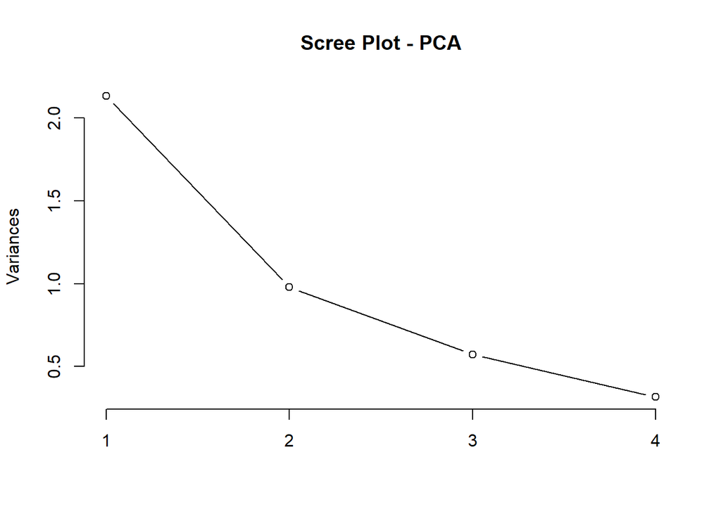

```r
# Scree plot (gráfico de codo)
plot(pca_result, type = "l", main = "Scree Plot - PCA")
```

```r
# Cargas de las variables (relación con los componentes)
pca_result$rotation
```

```
##                      PC1         PC2          PC3         PC4
## bedrooms      -0.5998697 -0.09390561 -0.309601467 -0.73176842
## bathrooms     -0.5231308 -0.06813457  0.845773250  0.07974637
## accommodates  -0.5898998 -0.07254281 -0.434517622  0.67672020
## num_amenities -0.1360470  0.99059424 -0.002996232 -0.01432725
```

```r
# Obtener los scores de los componentes principales
componentes <- as.data.frame(pca_result$x)

# Modelo de regresión con los dos primeros componentes
modelo_pca <- lm(pisos_filtrados$price ~ PC1 + PC2, data = cbind(componentes, pisos_filtrados$price))
summary(modelo_pca)
```

```
##
## Call:
## lm(formula = pisos_filtrados$price ~ PC1 + PC2, data = cbind(componentes,
##     pisos_filtrados$price))
##
## Residuals:
##     Min      1Q  Median      3Q     Max
## -165.61  -30.15   -8.73   16.16  919.60
##
## Coefficients:
##             Estimate Std. Error t value Pr(>|t|)
## (Intercept) 114.2630     1.0433 109.525  < 2e-16 ***
## PC1         -22.9117     0.7148 -32.054  < 2e-16 ***
## PC2          -4.0667     1.0546  -3.856 0.000117 ***
## ---
## Signif. codes:  0 '***' 0.001 '**' 0.01 '*' 0.05 '.' 0.1 ' ' 1
##
## Residual standard error: 61.1 on 3427 degrees of freedom
## Multiple R-squared:  0.2332, Adjusted R-squared:  0.2328
## F-statistic: 521.1 on 2 and 3427 DF,  p-value: < 2.2e-16
```

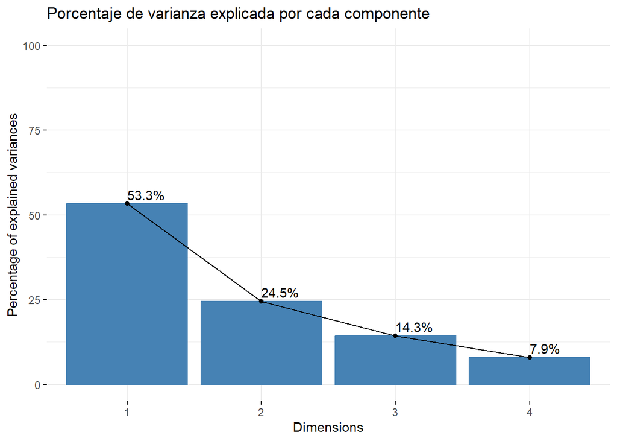

```r
# Seleccionar solo las variables numéricas predictoras
datos_pca <- pisos_filtrados[, c("bedrooms", "bathrooms", "accommodates", "num_amenities")]

# Hacer el PCA (escalando las variables)
pca <- prcomp(datos_pca, scale. = TRUE)
fviz_eig(pca, addlabels = TRUE, ylim = c(0, 100)) +
  ggtitle("Porcentaje de varianza explicada por cada componente")
```

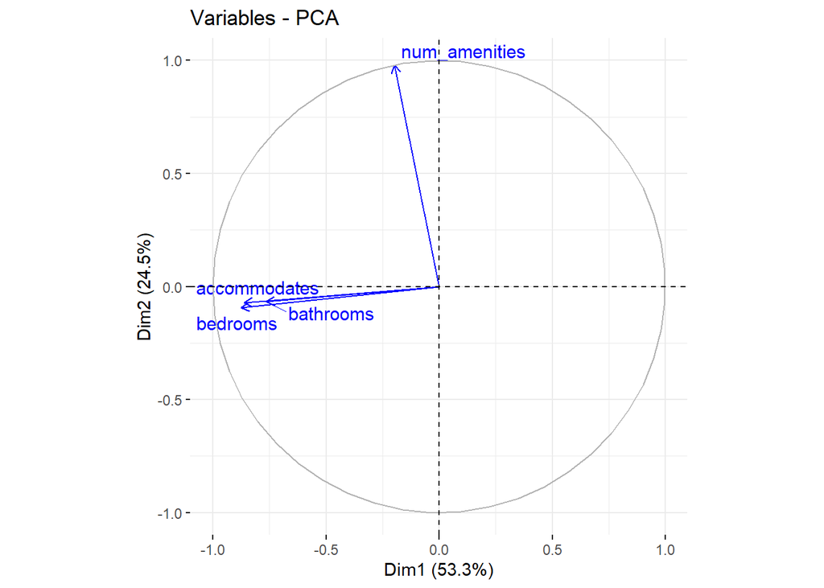

```r
fviz_pca_var(pca, repel = TRUE,
             col.var = "blue")  # Variables en azul
```

En este análisis, se consideró la posibilidad de aplicar Análisis de Componentes Principales (PCA) como técnica previa a la regresión lineal, con el objetivo de reducir la dimensionalidad del conjunto de predictores (bedrooms, bathrooms, accommodates, num_amenities) y comprobar si se podía mejorar el modelo.

Tras aplicar PCA, se observó que los dos primeros componentes explicaban aproximadamente un 77.74% de la varianza total. Se ajustó un modelo de regresión lineal utilizando estos dos componentes principales (PC1 y PC2) como variables predictoras.

Si bien el modelo con PCA mostró un R² ajustado de 0.2328, comparable al modelo original sin PCA (R² ajustado de 0.2363), se decidió no utilizar PCA en el modelo final por las siguientes razones:

- Pérdida de interpretabilidad: Los componentes principales son combinaciones lineales de las variables originales, lo que impide interpretar directamente el efecto de cada variable sobre el precio.
- Número reducido de variables: Dado que solo se utilizaron cuatro predictores, la reducción de dimensionalidad que ofrece el PCA es limitada y no justifica la pérdida de interpretabilidad.
- Modelo original significativo: El modelo sin PCA presentó resultados estadísticamente significativos para la mayoría de las variables, con coeficientes interpretables y un rendimiento similar al modelo con PCA.
- Enfoque explicativo: Dado que el objetivo del análisis es comprender qué factores influyen en el precio, es preferible trabajar directamente con las variables originales.

En consecuencia, se opta por mantener la regresión original sin aplicar PCA, priorizando la claridad y la interpretación del modelo.

```r
pisos_filtrados$precio_ponderado <- 8.73913 * pisos_filtrados$bedrooms + 14.73539 * pisos_filtrados$bathrooms + 11.95200 * pisos_filtrados$accommodates
```

Una vez creada la variable precio_ponderado, se calcula una relación media para comprobar si el piso es más caro de lo que debería (>1), está en buen precio(=1) o está más barato(<1):

```r
pisos_filtrados$peso <- pisos_filtrados$price / pisos_filtrados$precio_ponderado
```

Ahora vamos a ver si hay atípicos del precio ponderado de cada barrio.

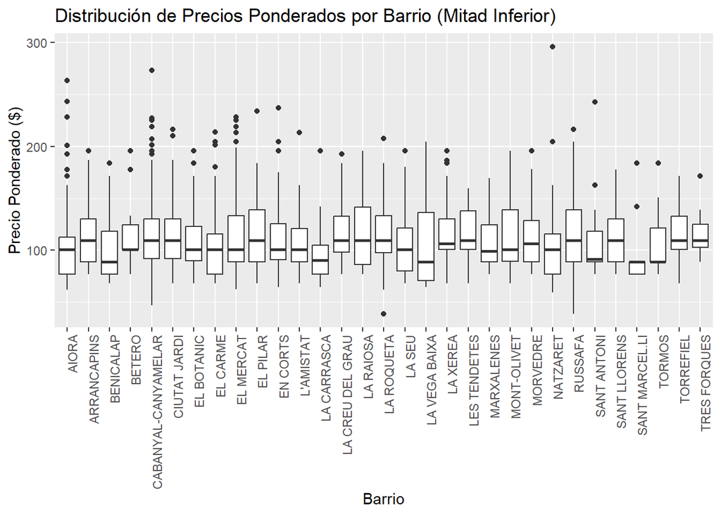

```r
# Calcular la media de los precios por barrio para los datos filtrados
precios_ponderados_por_barrio_filtrados <- pisos_filtrados %>%
  group_by(neighbourhood_cleansed) %>%
  summarise(media_precio_ponderado = mean(precio_ponderado, na.rm = TRUE))

# Ordenar los barrios por la media de los precios filtrados
precios_ponderados_por_barrio_filtrados <- precios_ponderados_por_barrio_filtrados %>%
  arrange(media_precio_ponderado)

# Dividir los barrios en dos grupos (la mitad inferior y la mitad superior por precio filtrado)
mitad_inferior_filtrada_ponderado <- precios_ponderados_por_barrio_filtrados[1:(nrow(precios_ponderados_por_barrio_filtrados) %/% 2), ]
mitad_superior_filtrada_ponderado <- precios_ponderados_por_barrio_filtrados[(nrow(precios_ponderados_por_barrio_filtrados) %/% 2 + 1):nrow(precios_ponderados_por_barrio_filtrados), ]

# Filtrar los datos originales para obtener solo los barrios de cada mitad
pisos_mitad_inferior_filtrada_ponderado <- pisos_filtrados %>%
  filter(neighbourhood_cleansed %in% mitad_inferior_filtrada_ponderado$neighbourhood_cleansed)

pisos_mitad_superior_filtrada_ponderado <- pisos_filtrados %>%
  filter(neighbourhood_cleansed %in% mitad_superior_filtrada_ponderado$neighbourhood_cleansed)

# Boxplot para la mitad inferior de barrios filtrados
ggplot(pisos_mitad_inferior_filtrada_ponderado, aes(x = neighbourhood_cleansed, y = precio_ponderado)) +
  geom_boxplot() +
  labs(title = "Distribución de Precios Ponderados por Barrio (Mitad Inferior)", x = "Barrio", y = "Precio Ponderado ($)") +
  theme(axis.text.x = element_text(angle = 90, hjust = 1))
```

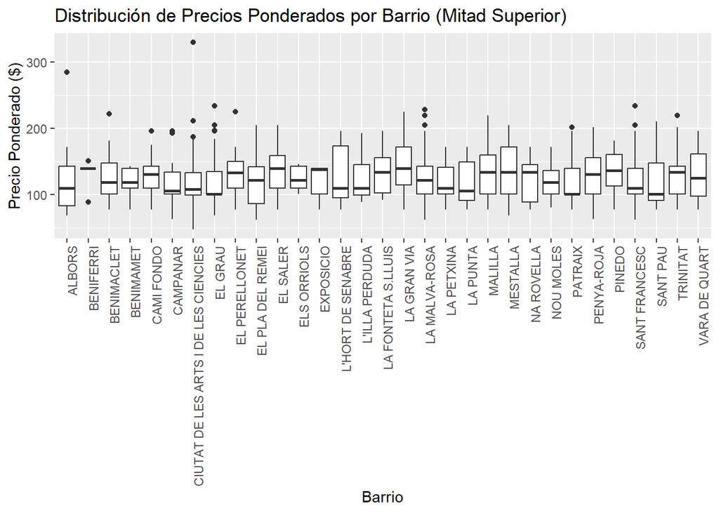

```r
# Boxplot para la mitad superior de barrios filtrados
ggplot(pisos_mitad_superior_filtrada_ponderado, aes(x = neighbourhood_cleansed, y = precio_ponderado)) +
  geom_boxplot() +
  labs(title = "Distribución de Precios Ponderados por Barrio (Mitad Superior)", x = "Barrio", y = "Precio Ponderado ($)") +
  theme(axis.text.x = element_text(angle = 90, hjust = 1))
```

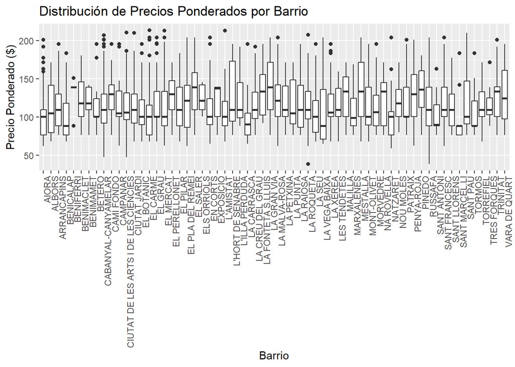

```r
pisos_limpios <- pisos_filtrados %>%
  filter(
    precio_ponderado > quantile(precio_ponderado, 0.25) - 1.5 * IQR(precio_ponderado) &
    precio_ponderado < quantile(precio_ponderado, 0.75) + 1.5 * IQR(precio_ponderado)
  )


# Boxplot para todos los barrios para comprobar ha funcionado
ggplot(pisos_limpios, aes(x = neighbourhood_cleansed, y = precio_ponderado)) +
  geom_boxplot() +
  labs(title = "Distribución de Precios Ponderados por Barrio", x = "Barrio", y = "Precio Ponderado ($)") +
  theme(axis.text.x = element_text(angle = 90, hjust = 1))
```

# CLUSTERING LIMPIEZA

Para comprobar que se ha realizado una buena limpieza de atípicos y un buen cálculo del precio ponderado, se va a realizar un clustering para observar si el precio se ajusta al precio ponderado, siendo un clúster los que se ajustan y otro los que no.

```r
zonas <- pisos_limpios %>%
  group_by(neighbourhood_cleansed) %>%
  summarise(
    precio_medio = mean(price, na.rm = TRUE),
    ponderado_medio = mean(precio_ponderado, na.rm = TRUE),
    relacion_precio_media = mean(peso, na.rm = TRUE),
    n = n()
  )
head(zonas)
```

```
## # A tibble: 6 × 5
##   neighbourhood_cleansed precio_medio ponderado_medio relacion_precio_media
##   <chr>                         <dbl>           <dbl>                 <dbl>
## 1 AIORA                          88.5            104.                 0.872
## 2 ALBORS                        122.             112.                 1.09
## 3 ARRANCAPINS                   118.             113.                 1.06
## 4 BENICALAP                      84.9            104.                 0.825
## 5 BENIFERRI                     128.             134.                 0.946
## 6 BENIMACLET                    118.             125.                 0.947
## # ℹ 1 more variable: n <int>
```

Parece que el dataset tiene buena forma así que se va a proceder al clustering, primero se calcula el nº óptimo de clusters:

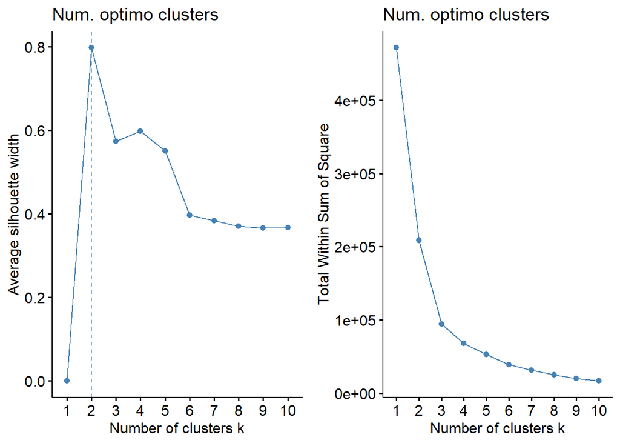

```r
p1 = fviz_nbclust(x = zonas, FUNcluster = hcut, method = "silhouette",
                  hc_method = "ward.D2", k.max = 10, verbose = FALSE,
                  hc_metric = "euclidean") + labs(title = "Num. optimo clusters")
p2 = fviz_nbclust(x = zonas, FUNcluster = hcut, method = "wss",
                  hc_method = "ward.D2", k.max = 10, verbose = FALSE,
                  hc_metric = "euclidean") + labs(title = "Num. optimo clusters")
grid.arrange(p1, p2, nrow = 1)
```

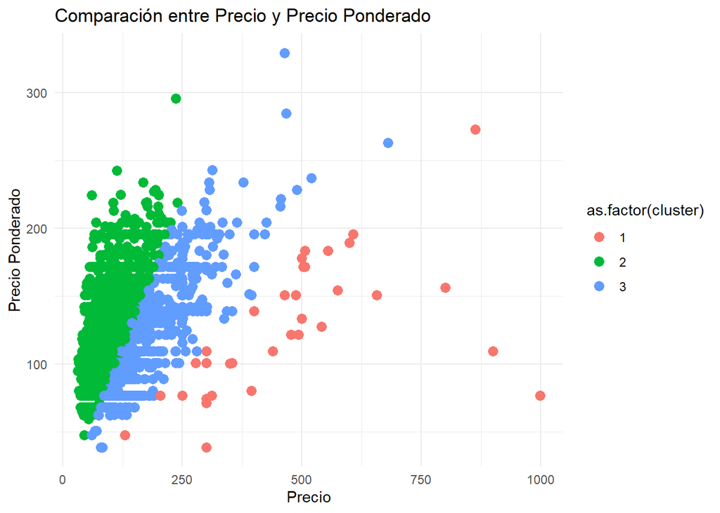

```r
# Seleccionar la columna 'peso' para el clustering y eliminar filas con NA, NaN o Inf
data_clean <- pisos_filtrados %>% filter(is.finite(peso))

# Realizar el clustering con k=3
kmeans_result <- kmeans(data_clean %>% select(peso), centers = 3)

# Añadir los resultados del clustering al dataframe limpio
data_clean$cluster <- kmeans_result$cluster


# Crear el gráfico de dispersión

ggplot(data_clean, aes(x = price, y = precio_ponderado, color = as.factor(cluster))) +
geom_point(size = 3) +
labs(title = "Comparación entre Precio y Precio Ponderado", x = "Precio", y = "Precio Ponderado") +
theme_minimal()
```

Ahora se va a realizar lo mismo pero por zonas:

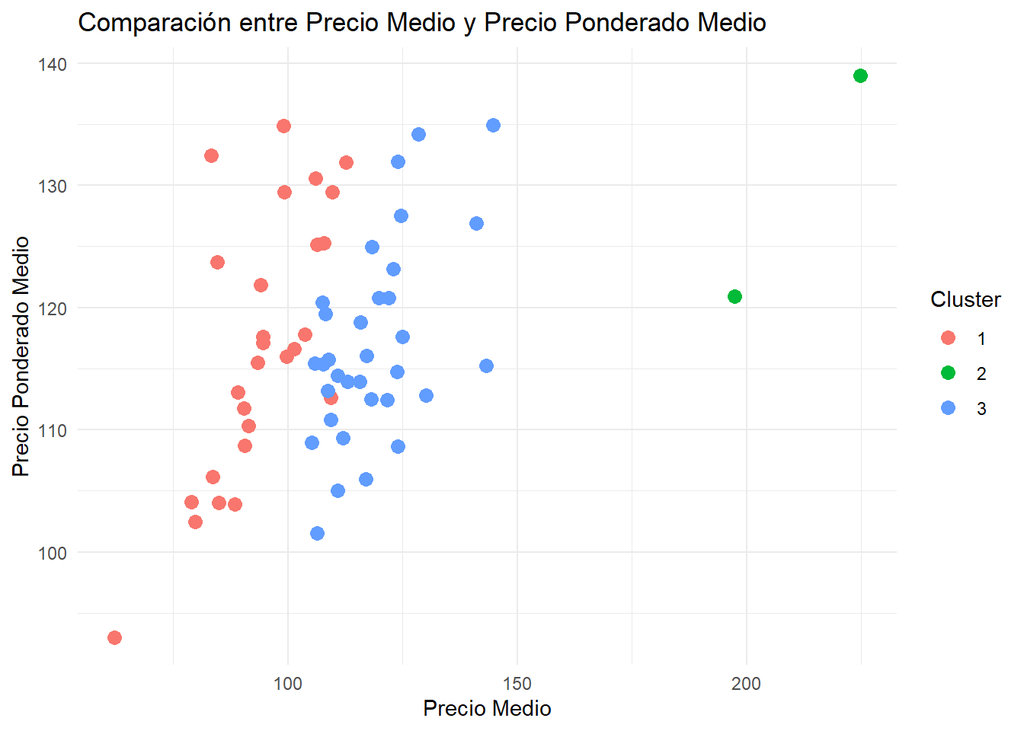

```r
# Seleccionar la columna 'relacion_precio_media' para el clustering y eliminar filas con NA, NaN o Inf
zonas_clean <- zonas %>% filter(is.finite(relacion_precio_media))

# Realizar el clustering con k=2
kmeans_result <- kmeans(zonas_clean %>% select(relacion_precio_media), centers = 3)

# Añadir los resultados del clustering al dataframe limpio
zonas_clean$cluster <- kmeans_result$cluster

# Crear el gráfico de dispersión
ggplot(zonas_clean, aes(x = precio_medio, y = ponderado_medio, color = as.factor(cluster))) +
  geom_point(size = 3) +
  labs(
    title = "Comparación entre Precio Medio y Precio Ponderado Medio",
    x = "Precio Medio",
    y = "Precio Ponderado Medio",
    color = "Cluster"
  ) +
  theme_minimal()
```

Un grupo central y estable (rojo),

Un grupo más disperso o atípico (verde),

En conjunto, este análisis pone en evidencia que el precio ponderado medio añade valor explicativo respecto al precio medio simple, al incorporar otros factores que afectan el valor real del inmueble.

Ahora observamos estos datos sobre un mapa:

```r
# Cambiar el nombre de la columna 'old_name' a 'new_name'
colnames(zonas_clean)[colnames(zonas_clean) == "neighbourhood_cleansed"] <- "nombre"

# Unir el GeoJSON con el dataframe de zonas utilizando 'nombre_barrio'
zonas_geojson <- left_join(barrios, zonas_clean, by = "nombre")
head(zonas_geojson)
```

```
## Simple feature collection with 6 features and 11 fields
## Geometry type: POLYGON
## Dimension:     XY
## Bounding box:  xmin: -0.3896127 ymin: 39.42278 xmax: -0.2876697 ymax: 39.56659
## Geodetic CRS:  WGS 84
##   coddistbar              nombre coddistrit codbarrio gis_gis_barrios_area
## 1        115            NATZARET         11         5              9171126
## 2        093     LA CREU COBERTA          9         3              3748875
## 3        133           L'AMISTAT         13         3              2072749
## 4        111             EL GRAU         11         1                   NA
## 5        175 RAFALELL-VISTABELLA         17         5                   NA
## 6        135         LA CARRASCA         13         5                   NA
##                                                 geo_point_2d precio_medio
## 1  { "lon": -0.3326600366971329, "lat": 39.446289648709062 }     79.80952
## 2  { "lon": -0.3853982961775011, "lat": 39.450827507483318 }           NA
```

[output cut: 18 more lines]

```r
# Definir los colores para los clusters
pal <- colorFactor(c("red", "blue","green"), domain = c(1, 2, 3))  # Ajusta los colores según tus clusters

# Crear el mapa choropleth
leaflet(data = zonas_geojson) %>%
  addTiles() %>%  # Añadir capa de mapas base
  addPolygons(
    fillColor = ~pal(cluster),  # Colorea las zonas según su cluster
    weight = 1,
    opacity = 1,
    color = "white",
    dashArray = "3",
    fillOpacity = 0.7,
    popup = ~paste("Barrio:", nombre, "<br>Cluster:", cluster)  # Mostrar información sobre cada zona
  ) %>%
  addLegend(
    position = "bottomright",
    pal = pal,
    values = ~cluster,
    title = "Clusters",
    opacity = 1
  )
```

[interactive chart not shown]

El mapa representa gráficamente cómo se distribuyen los clusters a nivel geográfico dentro del área de estudio.

Este mapa permite ver de forma clara la distribución espacial de los clusters:

Cluster 1 (Rojo): Barrios urbanos, consolidados, con precios más equilibrados.

Cluster 3 (Verde): Barrios periféricos, turísticos o menos homogéneos.

La eliminación de valores atípicos ha sido clave para obtener clusters significativos y consistentes. Al reducir el ruido en los datos, el clustering refleja patrones reales del mercado, diferenciando claramente zonas con precios más altos y homogéneos frente a otras más variables o con precios más bajos. Esta limpieza mejora la calidad del análisis y su interpretación tanto estadística como geográfica.

# ANÁLISIS PRECIO_PONDERADO

Ahora se realiza un nuevo mapa de calor, pero esta vez con precio_ponderado:

```r
# Calcular estadísticas por barrio
precios_zona <- pisos_limpios %>%
  group_by(neighbourhood_cleansed) %>%
  summarise(
    media_ponderado = mean(precio_ponderado, na.rm = TRUE)
  )

# Unir los datos espaciales con los precios
# Asegúrate de que el nombre de la columna en 'barrios' que contiene los nombres de los barrios coincida con 'neighbourhood_group_cleansed'
# Por ejemplo, si la columna se llama 'nombre_barrio', ajusta el código así:
barrios_precios <- barrios %>%
  left_join(precios_zona, by = c("nombre" = "neighbourhood_cleansed"))
```

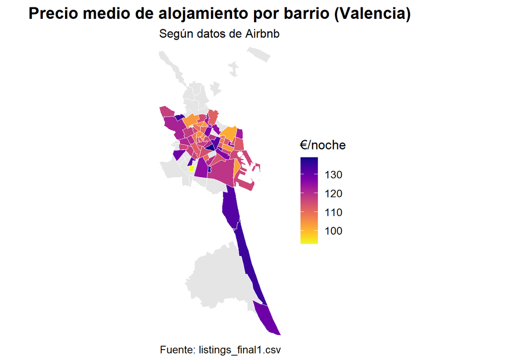

```r
ggplot(data = barrios_precios) +
  geom_sf(aes(fill = media_ponderado),
          color = "white",
          size = 0.3,
          show.legend = TRUE) +
  scale_fill_viridis(
    option = "plasma",
    name = "€/noche",
    na.value = "grey90",
    direction = -1
  ) +
  coord_sf(expand = FALSE) +
  labs(
    title = "Precio medio de alojamiento por barrio (Valencia)",
    subtitle = "Según datos de Airbnb",
    caption = "Fuente: listings_final1.csv"
  ) +
  theme_minimal(base_size = 13) +
  theme(
    legend.position = "right",
    plot.title = element_text(face = "bold", size = 16, hjust = 0.5),
    plot.subtitle = element_text(size = 12, hjust = 0.5),
    axis.text = element_blank(),
    axis.ticks = element_blank(),
    panel.grid = element_blank()
  )
```

```r
pisos_limpios %>%
  group_by(pisos_limpios$neighbourhood_group_cleansed, pisos_limpios$neighbourhood_cleansed) %>%
  summarise(
    media = mean(precio_ponderado, na.rm = TRUE),
    mediana = median(precio_ponderado, na.rm = TRUE),
    sd = sd(precio_ponderado, na.rm = TRUE),
    n = n()
  ) %>%
  arrange(desc(media))
```

[output not shown]

```
## # A tibble: 62 × 6
## # Groups:   pisos_limpios$neighbourhood_group_cleansed [18]
##    pisos_limpios$neighbourhoo…¹ pisos_limpios$neighb…² media mediana    sd     n
##    <chr>                        <chr>                  <dbl>   <dbl> <dbl> <int>
##  1 L'EIXAMPLE                   LA GRAN VIA             139.    139.  33.1    29
##  2 POBLATS DEL SUD              EL SALER                135.    139.  34.6    23
##  3 QUATRE CARRERES              LA FONTETA S.LLUIS      135.    133.  40.3     6
##  4 POBLATS DE L'OEST            BENIFERRI               134.    139.  18.8     8
##  5 POBLATS DEL SUD              PINEDO                  132.    136.  39.3     8
##  6 EL PLA DEL REAL              MESTALLA                132.    133.  40.2    41
##  7 JESUS                        L'HORT DE SENABRE       132.    109.  47.3    11
##  8 CAMINS AL GRAU               CAMI FONDO              131.    130.  37.4    15
##  9 POBLATS DEL SUD              EL PERELLONET           129.    130.  25.3    29
## 10 PATRAIX                      VARA DE QUART           129.    125.  39.9    11
## # ℹ 52 more rows
## # ℹ abbreviated names: ¹`pisos_limpios$neighbourhood_group_cleansed`,
## #   ²`pisos_limpios$neighbourhood_cleansed`
```

A pesar de estar fuera del centro urbano, la zona de Poblats del sud muestra precios medios de alojamiento significativamente altos. Esto resulta llamativo, dado que el modelo utilizado solo tiene en cuenta variables internas de los alojamientos (número de habitaciones, baños y capacidad), sin contemplar características externas como la ubicación o el entorno natural.

Este comportamiento sugiere que el entorno geográfico o el atractivo turístico del área, como su cercanía a la Albufera y playas naturales, podría estar influyendo en los precios, incluso sin haber sido incluido explícitamente en el análisis.

Este tipo de casos revela la importancia de la variable geográfica y sugiere que futuras versiones del modelo deberían considerar también factores espaciales y ambientales.

Otro caso curioso sería Beniferri, que muestra precios medios elevados en comparación con otras zonas cercanas, a pesar de no estar en pleno centro ni tener un perfil turístico tan marcado como Ciutat Vella o Ruzafa.

Teniendo en cuenta que el análisis solo se basa en variables internas del alojamiento (habitaciones, baños y capacidad), este resultado sugiere que en Beniferri podrían estar influyendo otros factores como:

- Proximidad a zonas de negocios o sedes corporativas (por ejemplo, Palacio de Congresos).
- Oferta de alojamientos modernos o de alta gama.
- Buena conectividad y accesos, lo que puede resultar atractivo para cierto perfil de viajeros.

Por último cabe destacar el caso de Malilla, aunque tradicionalmente ha sido un barrio residencial de clase media y algo más alejado del núcleo turístico, los precios medios de alojamiento son comparativamente altos en relación con barrios de perfil similar.

Este resultado es especialmente llamativo dado que el modelo solo considera variables como número de baños, habitaciones y capacidad, lo que sugiere que en Malilla podrían estar influyendo factores como:

- Su reciente transformación urbana (urbanizaciones nuevas, hospitales, zonas verdes).
- Cercanía al Hospital La Fe, lo cual puede generar demanda puntual (familias, personal médico, etc.).
- Atractivo para viajeros que buscan zonas tranquilas pero bien comunicadas.

Este caso refuerza la idea de que los factores urbanísticos y la evolución de los barrios deben considerarse en futuros análisis.

```r
write.csv(pisos_limpios, "pisos_limpios.csv")
```